# R Notebook

### Variable 10:

```r
table(var_21,var_10)
```

```
      var_10
var_21 A101 A102 A103
     1  577   21   34
     2  243   16    9
```

```r
prop.table(table(var_21,var_10))
```

```
      var_10
var_21       A101       A102       A103
     1 0.64111111 0.02333333 0.03777778
     2 0.27000000 0.01777778 0.01000000
```

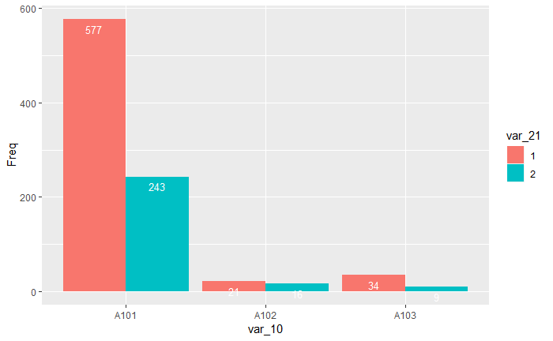

```r
ggplot(data=as.data.frame(table(var_21,var_10)), aes(x=var_10, y=Freq, fill=var_21)) +
  geom_bar(stat="identity", position=position_dodge())+
  geom_text(aes(label=Freq), vjust=1.6, color="white", position = position_dodge(0.9),size=3.5)
```

### Variable 11:

```r
table(var_21,var_11)
```

```
      var_11
var_21   1   2   3   4
     1  80 192  98 262
     2  32  89  39 108
```

```r
prop.table(table(var_21,var_11))
```

```
      var_11
var_21          1          2          3          4
     1 0.08888889 0.21333333 0.10888889 0.29111111
     2 0.03555556 0.09888889 0.04333333 0.12000000
```

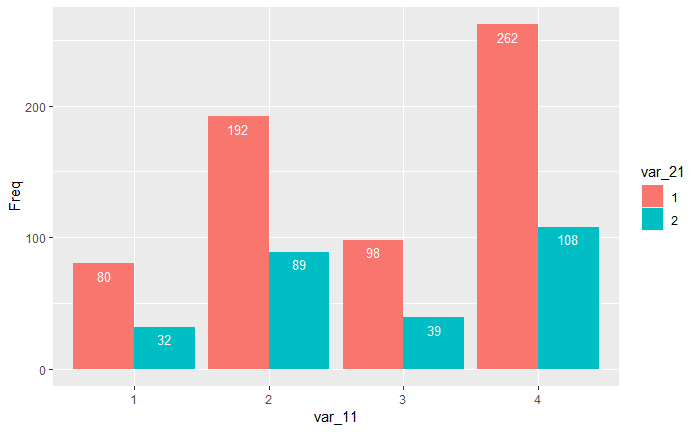

```r
ggplot(data=as.data.frame(table(var_21,var_11)), aes(x=var_11, y=Freq, fill=var_21)) +
  geom_bar(stat="identity", position=position_dodge())+
  geom_text(aes(label=Freq), vjust=1.6, color="white", position = position_dodge(0.9),size=3.5)
```

### Variable 12:

```r
table(var_21,var_12)
```

```
      var_12
var_21 A121 A122 A123 A124
     1  197  146  210   79
     2   54   68   88   58
```

```r
prop.table(table(var_21,var_12))
```

```
      var_12
var_21       A121       A122       A123       A124
     1 0.21888889 0.16222222 0.23333333 0.08777778
     2 0.06000000 0.07555556 0.09777778 0.06444444
```

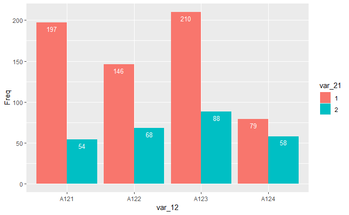

```r
ggplot(data=as.data.frame(table(var_21,var_12)), aes(x=var_12, y=Freq, fill=var_21)) +
  geom_bar(stat="identity", position=position_dodge())+
  geom_text(aes(label=Freq), vjust=1.6, color="white", position = position_dodge(0.9),size=3.5)
```

### Variable 14:

```r
table(var_21,var_14)
```

```
      var_14
var_21 A141 A142 A143
     1   75   25  532
     2   53   17  198
```

```r
prop.table(table(var_21,var_14))
```

```
      var_14
var_21       A141       A142       A143
     1 0.08333333 0.02777778 0.59111111
     2 0.05888889 0.01888889 0.22000000
```

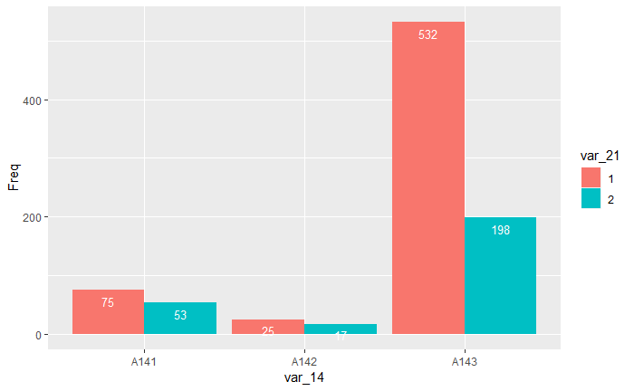

```r
ggplot(data=as.data.frame(table(var_21,var_14)), aes(x=var_14, y=Freq, fill=var_21)) +
  geom_bar(stat="identity", position=position_dodge())+
  geom_text(aes(label=Freq), vjust=1.6, color="white", position = position_dodge(0.9),size=3.5)
```

### Variable 15:

```r
table(var_21,var_15)
```

```
      var_15
var_21 A151 A152 A153
     1  102  471   59
     2   60  169   39
```

```r
prop.table(table(var_21,var_15))
```

```
      var_15
var_21       A151       A152       A153
     1 0.11333333 0.52333333 0.06555556
     2 0.06666667 0.18777778 0.04333333
```

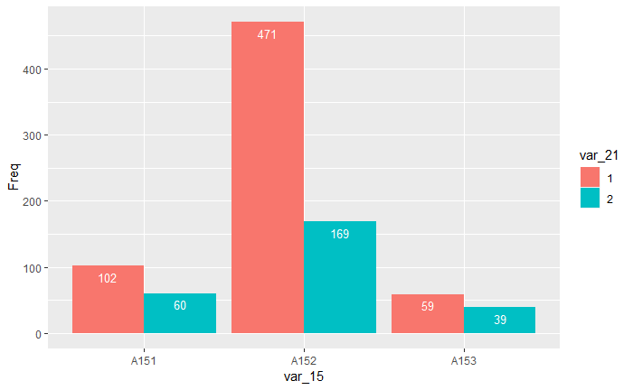

```r
ggplot(data=as.data.frame(table(var_21,var_15)), aes(x=var_15, y=Freq, fill=var_21)) +
  geom_bar(stat="identity", position=position_dodge())+
  geom_text(aes(label=Freq), vjust=1.6, color="white", position = position_dodge(0.9),size=3.5)
```

### Variable 16:

```r
table(var_21,var_16)
```

```
      var_16
var_21   1   2   3   4
     1 391 222  17   2
     2 180  82   4   2
```

```r
prop.table(table(var_21,var_16))
```

```
      var_16
var_21           1           2           3           4
     1 0.434444444 0.246666667 0.018888889 0.002222222
     2 0.200000000 0.091111111 0.004444444 0.002222222
```

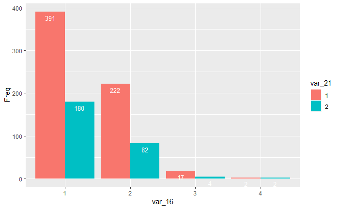

```r
ggplot(data=as.data.frame(table(var_21,var_16)), aes(x=var_16, y=Freq, fill=var_21)) +
  geom_bar(stat="identity", position=position_dodge())+
  geom_text(aes(label=Freq), vjust=1.6, color="white", position = position_dodge(0.9),size=3.5)
```

### Variable 17:

```r
table(var_21,var_17)
```

```
      var_17
var_21 A171 A172 A173 A174
     1   13  130  401   88
     2    6   50  168   44
```

```r
prop.table(table(var_21,var_17))
```

```
      var_17
var_21        A171        A172        A173        A174
     1 0.014444444 0.144444444 0.445555556 0.097777778
     2 0.006666667 0.055555556 0.186666667 0.048888889
```

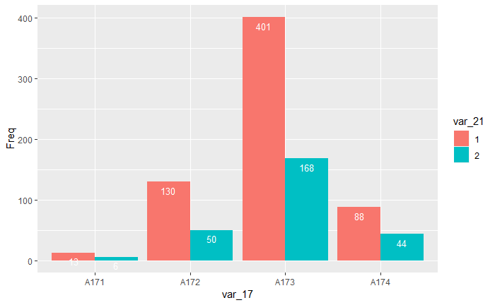

```r
ggplot(data=as.data.frame(table(var_21,var_17)), aes(x=var_17, y=Freq, fill=var_21)) +
  geom_bar(stat="identity", position=position_dodge())+
  geom_text(aes(label=Freq), vjust=1.6, color="white", position = position_dodge(0.9),size=3.5)
```

### Variable 18:

```r
table(var_21,var_18)
```

```
      var_18
var_21   1   2
     1 535  97
     2 232  36
```

```r
prop.table(table(var_21,var_18))
```

```
      var_18
var_21         1         2
     1 0.5944444 0.1077778
     2 0.2577778 0.0400000
```

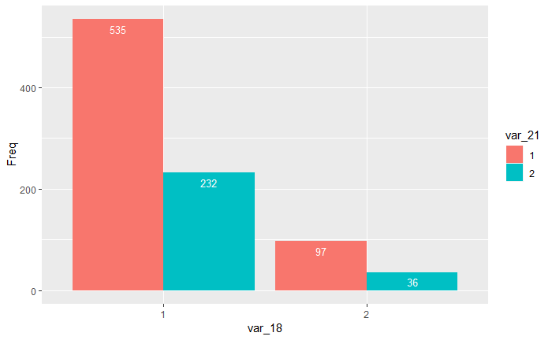

```r
ggplot(data=as.data.frame(table(var_21,var_18)), aes(x=var_18, y=Freq, fill=var_21)) +
  geom_bar(stat="identity", position=position_dodge())+
  geom_text(aes(label=Freq), vjust=1.6, color="white", position = position_dodge(0.9),size=3.5)
```

### Variable 19:

```r
table(var_21,var_19)
```

```
      var_19
var_21 A191 A192
     1  365  267
     2  166  102
```

```r
prop.table(table(var_21,var_19))
```

```
      var_19
var_21      A191      A192
     1 0.4055556 0.2966667
     2 0.1844444 0.1133333
```

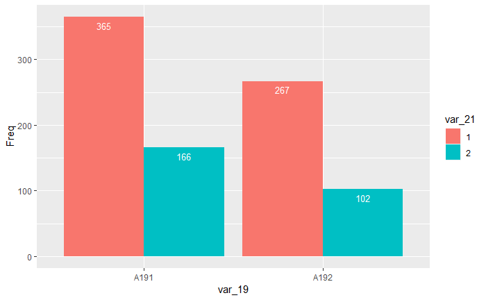

```r
ggplot(data=as.data.frame(table(var_21,var_19)), aes(x=var_19, y=Freq, fill=var_21)) +
  geom_bar(stat="identity", position=position_dodge())+
  geom_text(aes(label=Freq), vjust=1.6, color="white", position = position_dodge(0.9),size=3.5)
```

### Variable 20:

```r
table(var_21,var_20)
```

```
      var_20
var_21 A201 A202
     1  601   31
     2  264    4
```

```r
prop.table(table(var_21,var_20))
```

```
      var_20
var_21        A201        A202
     1 0.667777778 0.034444444
     2 0.293333333 0.004444444
```

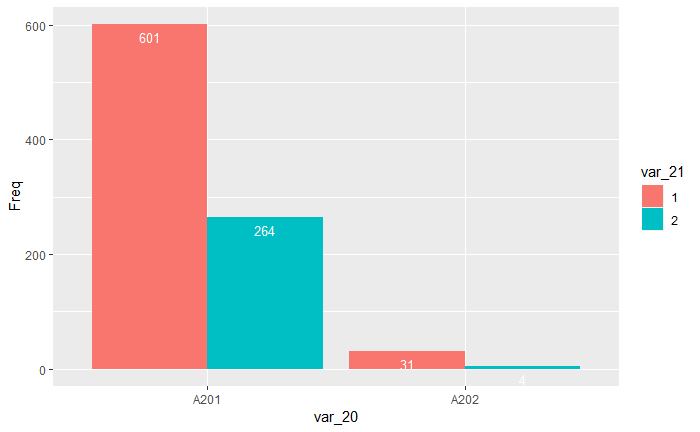

```r
ggplot(data=as.data.frame(table(var_21,var_20)), aes(x=var_20, y=Freq, fill=var_21)) +
  geom_bar(stat="identity", position=position_dodge())+
  geom_text(aes(label=Freq), vjust=1.6, color="white", position = position_dodge(0.9),size=3.5)
```

# Base entrenamiento y base testing

```
      var_21
var_21   1   2
     1 474   0
     2   0 201
      var_21
var_21         1         2
     1 0.7022222 0.0000000
     2 0.0000000 0.2977778
```

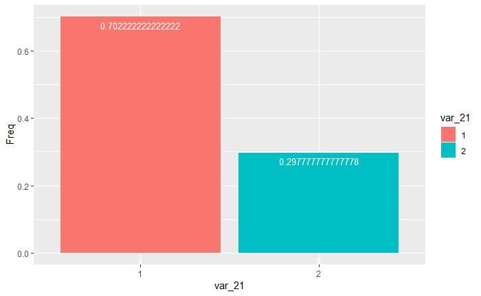

```
      var_21
var_21   1   2
     1 158   0
     2   0  67
      var_21
var_21         1         2
     1 0.7022222 0.0000000
     2 0.0000000 0.2977778
```

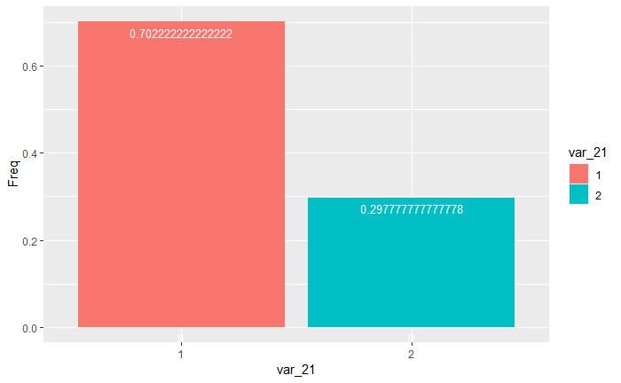

# Modelamiento - Scorecard

## Binning

| variable | bin | count | count_distr | good | bad | badprob | woe | bin_iv | total_iv | breaks | is_special_values |
| --- | --- | --- | --- | --- | --- | --- | --- | --- | --- | --- | --- |
| var_1 | A14 | 258 | 0.38222222 | 230 | 28 | 0.1085271 | -1.2479724 | 0.431709321 | 0.657615 | A14 | FALSE |
| var_1 | A13 | 46 | 0.06814815 | 35 | 11 | 0.2391304 | -0.2995504 | 0.005725394 | 0.657615 | A13 | FALSE |
| var_1 | A12%,%A11 | 371 | 0.54962963 | 209 | 162 | 0.4366577 | 0.6031645 | 0.220180301 | 0.657615 | A12%,%A11 | FALSE |

| variable | bin | count | count_distr | good | bad | badprob | woe | bin_iv | total_iv | breaks | is_special_values |
| --- | --- | --- | --- | --- | --- | --- | --- | --- | --- | --- | --- |
| var_2 | [-Inf,8) | 61 | 0.09037037 | 55 | 6 | 0.09836066 | -1.35767130 | 0.117008198 | 0.2463264 | 8 | FALSE |
| var_2 | [8,16) | 238 | 0.35259259 | 180 | 58 | 0.24369748 | -0.27461143 | 0.025041712 | 0.2463264 | 16 | FALSE |
| var_2 | [16,30) | 237 | 0.35111111 | 163 | 74 | 0.31223629 | 0.06821731 | 0.001656135 | 0.2463264 | 30 | FALSE |
| var_2 | [30, Inf) | 139 | 0.20592593 | 76 | 63 | 0.45323741 | 0.67030380 | 0.102620350 | 0.2463264 | Inf | FALSE |

| variable | bin | count | count_distr | good | bad | badprob | woe | bin_iv | total_iv | breaks | is_special_values |
| --- | --- | --- | --- | --- | --- | --- | --- | --- | --- | --- | --- |
| var_3 | A34 | 195 | 0.28888889 | 156 | 39 | 0.2000000 | -0.52839195 | 0.0713773366 | 0.2147991 | A34 | FALSE |
| var_3 | A32 | 360 | 0.53333333 | 251 | 109 | 0.3027778 | 0.02379736 | 0.0003034804 | 0.2147991 | A32 | FALSE |
| var_3 | A33 | 62 | 0.09185185 | 43 | 19 | 0.3064516 | 0.04114128 | 0.0001567509 | 0.2147991 | A33 | FALSE |
| var_3 | A31%,%A30 | 58 | 0.08592593 | 24 | 34 | 0.5862069 | 1.20620911 | 0.1429614926 | 0.2147991 | A31%,%A30 | FALSE |

| variable | bin | count | count_distr | good | bad | badprob | woe | bin_iv | total_iv | breaks | is_special_values |
| --- | --- | --- | --- | --- | --- | --- | --- | --- | --- | --- | --- |
| var_4 | A48%,%A41 | 75 | 0.1111111 | 63 | 12 | 0.1600000 | -0.80032566 | 5.859176e-02 | 0.166244 | A48%,%A41 | FALSE |
| var_4 | A44%,%A43 | 192 | 0.2844444 | 149 | 43 | 0.2239583 | -0.38484378 | 3.864434e-02 | 0.166244 | A44%,%A43 | FALSE |
| var_4 | A45%,%A42 | 140 | 0.2074074 | 98 | 42 | 0.3000000 | 0.01060455 | 2.337423e-05 | 0.166244 | A45%,%A42 | FALSE |
| var_4 | A40%,%A49%,%A410%,%A46 | 268 | 0.3970370 | 164 | 104 | 0.3880597 | 0.40242688 | 6.898457e-02 | 0.166244 | A40%,%A49%,%A410%,%A46 | FALSE |

| variable | bin | count | count_distr | good | bad | badprob | woe | bin_iv | total_iv | breaks | is_special_values |
| --- | --- | --- | --- | --- | --- | --- | --- | --- | --- | --- | --- |
| var_5 | [-Inf,1400) | 177 | 0.26222222 | 121 | 56 | 0.3163842 | 0.08746356 | 0.0020407613 | 0.2453852 | 1400 | FALSE |
| var_5 | [1400,1800) | 74 | 0.10962963 | 63 | 11 | 0.1486486 | -0.88733704 | 0.0693764680 | 0.2453852 | 1800 | FALSE |
| var_5 | [1800,3200) | 181 | 0.26814815 | 130 | 51 | 0.2817680 | -0.07780640 | 0.0015973857 | 0.2453852 | 3200 | FALSE |
| var_5 | [3200,4000) | 76 | 0.11259259 | 63 | 13 | 0.1710526 | -0.72028296 | 0.0491483457 | 0.2453852 | 4000 | FALSE |
| var_5 | [4000,5000) | 42 | 0.06222222 | 24 | 18 | 0.4285714 | 0.57022034 | 0.0221925922 | 0.2453852 | 5000 | FALSE |
| var_5 | [5000,7800) | 70 | 0.10370370 | 48 | 22 | 0.3142857 | 0.07774386 | 0.0006364822 | 0.2453852 | 7800 | FALSE |
| var_5 | [7800, Inf) | 55 | 0.08148148 | 25 | 30 | 0.5454545 | 1.04022397 | 0.1003931756 | 0.2453852 | Inf | FALSE |

| variable | bin | count | count_distr | good | bad | badprob | woe | bin_iv | total_iv | breaks | is_special_values |
| --- | --- | --- | --- | --- | --- | --- | --- | --- | --- | --- | --- |
| var_6 | A63 | 44 | 0.06518519 | 38 | 6 | 0.1363636 | -0.9879243 | 0.04971040 | 0.2101961 | A63 | FALSE |
| var_6 | A64%,%A65 | 156 | 0.23111111 | 130 | 26 | 0.1666667 | -0.7515355 | 0.10890378 | 0.2101961 | A64%,%A65 | FALSE |
| var_6 | A62%,%A61 | 475 | 0.70370370 | 306 | 169 | 0.3557895 | 0.2642160 | 0.05158194 | 0.2101961 | A62%,%A61 | FALSE |

| variable | bin | count | count_distr | good | bad | badprob | woe | bin_iv | total_iv | breaks | is_special_values |
| --- | --- | --- | --- | --- | --- | --- | --- | --- | --- | --- | --- |
| var_7 | A74 | 124 | 0.18370370 | 95 | 29 | 0.2338710 | -0.3286786 | 0.018453115 | 0.07403291 | A74 | FALSE |
| var_7 | A75%,%A73 | 395 | 0.58518519 | 285 | 110 | 0.2784810 | -0.0941064 | 0.005081947 | 0.07403291 | A75%,%A73 | FALSE |
| var_7 | A71 | 49 | 0.07259259 | 31 | 18 | 0.3673469 | 0.3142870 | 0.007590469 | 0.07403291 | A71 | FALSE |
| var_7 | A72 | 107 | 0.15851852 | 63 | 44 | 0.4112150 | 0.4989573 | 0.042907376 | 0.07403291 | A72 | FALSE |

| variable | bin | count | count_distr | good | bad | badprob | woe | bin_iv | total_iv | breaks | is_special_values |
| --- | --- | --- | --- | --- | --- | --- | --- | --- | --- | --- | --- |
| var_8 | [-Inf,2) | 87 | 0.1288889 | 70 | 17 | 0.1954023 | -0.55737948 | 3.517188e-02 | 0.04406493 | 2 | FALSE |
| var_8 | [2,3) | 163 | 0.2414815 | 114 | 49 | 0.3006135 | 0.01352426 | 4.428879e-05 | 0.04406493 | 3 | FALSE |
| var_8 | [3,4) | 100 | 0.1481481 | 71 | 29 | 0.2900000 | -0.03748163 | 2.065396e-04 | 0.04406493 | 4 | FALSE |
| var_8 | [4, Inf) | 325 | 0.4814815 | 219 | 106 | 0.3261538 | 0.13226978 | 8.642225e-03 | 0.04406493 | Inf | FALSE |

| variable | bin | count | count_distr | good | bad | badprob | woe | bin_iv | total_iv | breaks | is_special_values |
| --- | --- | --- | --- | --- | --- | --- | --- | --- | --- | --- | --- |
| var_9 | A93 | 365 | 0.54074074 | 273 | 92 | 0.2520548 | -0.2297808 | 0.027168805 | 0.07283603 | A93 | FALSE |
| var_9 | A94 | 63 | 0.09333333 | 46 | 17 | 0.2698413 | -0.1375256 | 0.001714848 | 0.07283603 | A94 | FALSE |
| var_9 | A92%,%A91 | 247 | 0.36592593 | 155 | 92 | 0.3724696 | 0.3362659 | 0.043952379 | 0.07283603 | A92%,%A91 | FALSE |

| variable | bin | count | count_distr | good | bad | badprob | woe | bin_iv | total_iv | breaks | is_special_values |
| --- | --- | --- | --- | --- | --- | --- | --- | --- | --- | --- | --- |
| var_10 | A103%,%A101%,%A102 | 675 | 1 | 474 | 201 | 0.2977778 | 0 | 0 | 0 | A103%,%A101%,%A102 | FALSE |

| variable | bin | count | count_distr | good | bad | badprob | woe | bin_iv | total_iv | breaks | is_special_values |
| --- | --- | --- | --- | --- | --- | --- | --- | --- | --- | --- | --- |
| var_11 | [-Inf,2) | 85 | 0.1259259 | 62 | 23 | 0.2705882 | -0.13373776 | 0.0021897989 | 0.01018612 | 2 | FALSE |
| var_11 | [2,3) | 207 | 0.3066667 | 139 | 68 | 0.3285024 | 0.14293619 | 0.0064406349 | 0.01018612 | 3 | FALSE |
| var_11 | [3,4) | 106 | 0.1570370 | 76 | 30 | 0.2830189 | -0.07163354 | 0.0007939734 | 0.01018612 | 4 | FALSE |
| var_11 | [4, Inf) | 277 | 0.4103704 | 197 | 80 | 0.2888087 | -0.04327468 | 0.0007617150 | 0.01018612 | Inf | FALSE |

| variable | bin | count | count_distr | good | bad | badprob | woe | bin_iv | total_iv | breaks | is_special_values |
| --- | --- | --- | --- | --- | --- | --- | --- | --- | --- | --- | --- |
| var_12 | A121 | 196 | 0.2903704 | 156 | 40 | 0.2040816 | -0.50307414 | 0.0654544475 | 0.117848 | A121 | FALSE |
| var_12 | A122 | 163 | 0.2414815 | 113 | 50 | 0.3067485 | 0.04253760 | 0.0004406723 | 0.117848 | A122 | FALSE |
| var_12 | A123 | 217 | 0.3214815 | 148 | 69 | 0.3179724 | 0.09479664 | 0.0029431794 | 0.117848 | A123 | FALSE |
| var_12 | A124 | 99 | 0.1466667 | 57 | 42 | 0.4242424 | 0.55252076 | 0.0490097296 | 0.117848 | A124 | FALSE |

| variable | bin | count | count_distr | good | bad | badprob | woe | bin_iv | total_iv | breaks | is_special_values |
| --- | --- | --- | --- | --- | --- | --- | --- | --- | --- | --- | --- |
| var_13 | [-Inf,24) | 67 | 0.09925926 | 45 | 22 | 0.3283582 | 0.14228238 | 2.065375e-03 | 0.167381 | 24 | FALSE |
| var_13 | [24,26) | 62 | 0.09185185 | 32 | 30 | 0.4838710 | 0.79336389 | 6.485209e-02 | 0.167381 | 26 | FALSE |
| var_13 | [26,35) | 238 | 0.35259259 | 162 | 76 | 0.3193277 | 0.10103942 | 3.671500e-03 | 0.167381 | 35 | FALSE |
| var_13 | [35,42) | 131 | 0.19407407 | 101 | 30 | 0.2290076 | -0.35602072 | 2.272353e-02 | 0.167381 | 42 | FALSE |
| var_13 | [42,45) | 36 | 0.05333333 | 24 | 12 | 0.3333333 | 0.16475523 | 1.494096e-03 | 0.167381 | 45 | FALSE |
| var_13 | [45,53) | 75 | 0.11111111 | 64 | 11 | 0.1466667 | -0.90308540 | 7.251300e-02 | 0.167381 | 53 | FALSE |
| var_13 | [53, Inf) | 66 | 0.09777778 | 46 | 20 | 0.3030303 | 0.02499329 | 6.138537e-05 | 0.167381 | Inf | FALSE |

| variable | bin | count | count_distr | good | bad | badprob | woe | bin_iv | total_iv | breaks | is_special_values |
| --- | --- | --- | --- | --- | --- | --- | --- | --- | --- | --- | --- |
| var_14 | A143 | 547 | 0.8103704 | 402 | 145 | 0.2650823 | -0.1618159 | 0.02050341 | 0.0973631 | A143 | FALSE |
| var_14 | A142%,%A141 | 128 | 0.1896296 | 72 | 56 | 0.4375000 | 0.6065880 | 0.07685969 | 0.0973631 | A142%,%A141 | FALSE |

| variable | bin | count | count_distr | good | bad | badprob | woe | bin_iv | total_iv | breaks | is_special_values |
| --- | --- | --- | --- | --- | --- | --- | --- | --- | --- | --- | --- |
| var_15 | A152 | 479 | 0.7096296 | 354 | 125 | 0.2609603 | -0.1830808 | 0.02287501 | 0.07620464 | A152 | FALSE |
| var_15 | A151 | 127 | 0.1881481 | 80 | 47 | 0.3700787 | 0.3260234 | 0.02120928 | 0.07620464 | A151 | FALSE |
| var_15 | A153 | 69 | 0.1022222 | 40 | 29 | 0.4202899 | 0.5363188 | 0.03212036 | 0.07620464 | A153 | FALSE |

| variable | bin | count | count_distr | good | bad | badprob | woe | bin_iv | total_iv | breaks | is_special_values |
| --- | --- | --- | --- | --- | --- | --- | --- | --- | --- | --- | --- |
| var_16 | [-Inf,2) | 431 | 0.6385185 | 298 | 133 | 0.3085847 | 0.05115806 | 0.001688193 | 0.00475959 | 2 | FALSE |
| var_16 | [2, Inf) | 244 | 0.3614815 | 176 | 68 | 0.2786885 | -0.09307388 | 0.003071397 | 0.00475959 | Inf | FALSE |

| variable | bin | count | count_distr | good | bad | badprob | woe | bin_iv | total_iv | breaks | is_special_values |
| --- | --- | --- | --- | --- | --- | --- | --- | --- | --- | --- | --- |
| var_17 | A172%,%A171 | 148 | 0.2192593 | 111 | 37 | 0.2500000 | -0.240709875 | 1.205899e-02 | 0.02594042 | A172%,%A171 | FALSE |
| var_17 | A173 | 422 | 0.6251852 | 296 | 126 | 0.2985782 | 0.003824866 | 9.153279e-06 | 0.02594042 | A173 | FALSE |
| var_17 | A174 | 105 | 0.1555556 | 67 | 38 | 0.3619048 | 0.290795954 | 1.387228e-02 | 0.02594042 | A174 | FALSE |

| variable | bin | count | count_distr | good | bad | badprob | woe | bin_iv | total_iv | breaks | is_special_values |
| --- | --- | --- | --- | --- | --- | --- | --- | --- | --- | --- | --- |
| var_18 | [-Inf,2) | 577 | 0.8548148 | 401 | 176 | 0.305026 | 0.03442498 | 0.001020024 | 0.007351468 | 2 | FALSE |
| var_18 | [2, Inf) | 98 | 0.1451852 | 73 | 25 | 0.255102 | -0.21368120 | 0.006331444 | 0.007351468 | Inf | FALSE |

| variable | bin | count | count_distr | good | bad | badprob | woe | bin_iv | total_iv | breaks | is_special_values |
| --- | --- | --- | --- | --- | --- | --- | --- | --- | --- | --- | --- |
| var_19 | A192 | 277 | 0.4103704 | 199 | 78 | 0.2815884 | -0.07869358 | 0.002500215 | 0.004194135 | A192 | FALSE |
| var_19 | A191 | 398 | 0.5896296 | 275 | 123 | 0.3090452 | 0.05331567 | 0.001693920 | 0.004194135 | A191 | FALSE |

| variable | bin | count | count_distr | good | bad | badprob | woe | bin_iv | total_iv | breaks | is_special_values |
| --- | --- | --- | --- | --- | --- | --- | --- | --- | --- | --- | --- |
| var_20 | A202%,%A201 | 675 | 1 | 474 | 201 | 0.2977778 | 0 | 0 | 0 | A202%,%A201 | FALSE |

```
NA
```

## Information Value

En la siguiente tabla se encuentra los valores para determinar que tan buen predictor es la variable:

| Information Value | Poder predictivo |
| --- | --- |
| < 0.02 | Sin poder predictivo |
| 0.02 to 0.1 | Bajo |
| 0.1 to 0.3 | Medio |
| > 0.3 | Alto |

| variable | info_value |
| --- | --- |
| var_1_woe | 0.657615017 |
| var_2_woe | 0.246326395 |
| var_5_woe | 0.245385211 |
| var_3_woe | 0.214799060 |
| var_6_woe | 0.210196131 |
| var_13_woe | 0.167380977 |
| var_4_woe | 0.166244041 |
| var_12_woe | 0.117848029 |
| var_14_woe | 0.097363101 |
| var_15_woe | 0.076204645 |

[output cut: 10 more lines]

Por lo tanto, las variables utilizadas para evaluar un modelo completo serán las primeras 13 variables

## Modificación binning

En las siguientes imagenes, se encuentran las variables con los cortes de WoEs modificados. Los criterios para modificar los WoEs fueron los siguientes:

1. Poblamiento de la categoría, es decir, esta debe tener un poblamiento mayor o igual al 5% respecto al total de la distribución.
2. Bad Rate debe ser monotonamente creciente o decreciente.
3. Realizar la menor cantidad de modificaciones para no el IV.

A continuación, se encuentra el resumen de las 13 variables con mejor poder predictivo. Esto con las modificaciones realizadas.

### Variable 1:

| variable | bin | count | count_distr | good | bad | badprob | woe | bin_iv | total_iv | breaks | is_special_values |
| --- | --- | --- | --- | --- | --- | --- | --- | --- | --- | --- | --- |
| var_1 | A14 | 258 | 0.38222222 | 28 | 230 | 0.8914729 | 1.2479724 | 0.431709321 | 0.657615 | A14 | FALSE |
| var_1 | A13 | 46 | 0.06814815 | 11 | 35 | 0.7608696 | 0.2995504 | 0.005725394 | 0.657615 | A13 | FALSE |
| var_1 | A12%,%A11 | 371 | 0.54962963 | 162 | 209 | 0.5633423 | -0.6031645 | 0.220180301 | 0.657615 | A12%,%A11 | FALSE |

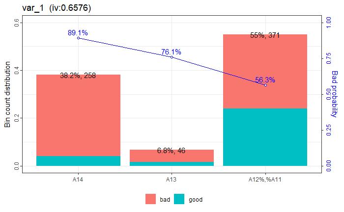

### Variable 2:

| variable | bin | count | count_distr | good | bad | badprob | woe | bin_iv | total_iv | breaks | is_special_values |
| --- | --- | --- | --- | --- | --- | --- | --- | --- | --- | --- | --- |
| var_2 | [-Inf,8) | 61 | 0.09037037 | 6 | 55 | 0.9016393 | 1.35767130 | 0.117008198 | 0.2463264 | 8 | FALSE |
| var_2 | [8,16) | 238 | 0.35259259 | 58 | 180 | 0.7563025 | 0.27461143 | 0.025041712 | 0.2463264 | 16 | FALSE |
| var_2 | [16,30) | 237 | 0.35111111 | 74 | 163 | 0.6877637 | -0.06821731 | 0.001656135 | 0.2463264 | 30 | FALSE |
| var_2 | [30, Inf) | 139 | 0.20592593 | 63 | 76 | 0.5467626 | -0.67030380 | 0.102620350 | 0.2463264 | Inf | FALSE |

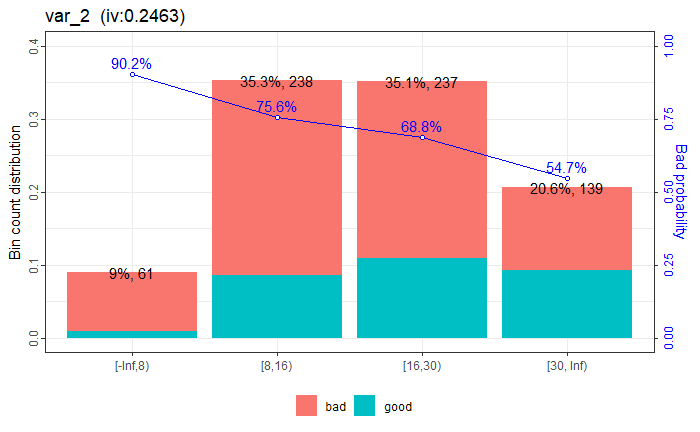

### Variable 5:

| variable | bin | count | count_distr | good | bad | badprob | woe | bin_iv | total_iv | breaks | is_special_values |
| --- | --- | --- | --- | --- | --- | --- | --- | --- | --- | --- | --- |
| var_5 | [-Inf,4000) | 508 | 0.75259259 | 131 | 377 | 0.7421260 | 0.1991455 | 0.02860074 | 0.1417181 | 4000 | FALSE |
| var_5 | [4000,7800) | 112 | 0.16592593 | 40 | 72 | 0.6428571 | -0.2701157 | 0.01272414 | 0.1417181 | 7800 | FALSE |
| var_5 | [7800, Inf) | 55 | 0.08148148 | 30 | 25 | 0.4545455 | -1.0402240 | 0.10039318 | 0.1417181 | Inf | FALSE |

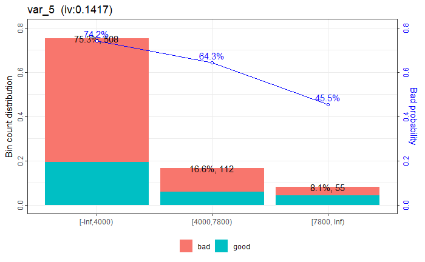

### Variable 3:

| variable | bin | count | count_distr | good | bad | badprob | woe | bin_iv | total_iv | breaks | is_special_values |
| --- | --- | --- | --- | --- | --- | --- | --- | --- | --- | --- | --- |
| var_3 | A30%,%A31 | 58 | 0.08592593 | 34 | 24 | 0.4137931 | -1.20620911 | 0.1429614926 | 0.1924874 | A30%,%A31 | FALSE |
| var_3 | A32 | 360 | 0.53333333 | 109 | 251 | 0.6972222 | -0.02379736 | 0.0003034804 | 0.1924874 | A32 | FALSE |
| var_3 | A33%,%A34 | 257 | 0.38074074 | 58 | 199 | 0.7743191 | 0.37495940 | 0.0492224240 | 0.1924874 | A33%,%A34 | FALSE |

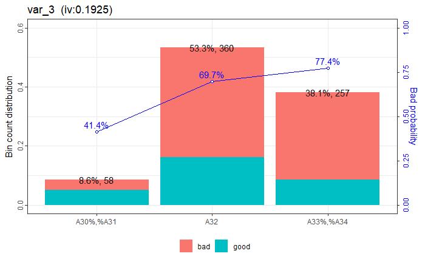

### Variable 6:

| variable | bin | count | count_distr | good | bad | badprob | woe | bin_iv | total_iv | breaks | is_special_values |
| --- | --- | --- | --- | --- | --- | --- | --- | --- | --- | --- | --- |
| var_6 | A65%,%A61 | 532 | 0.7881481 | 168 | 364 | 0.6842105 | -0.08471253 | 0.005750998 | 0.02924517 | A65%,%A61 | FALSE |
| var_6 | A62%,%A63%,%A64 | 143 | 0.2118519 | 33 | 110 | 0.7692308 | 0.34607039 | 0.023494167 | 0.02924517 | A62%,%A63%,%A64 | FALSE |

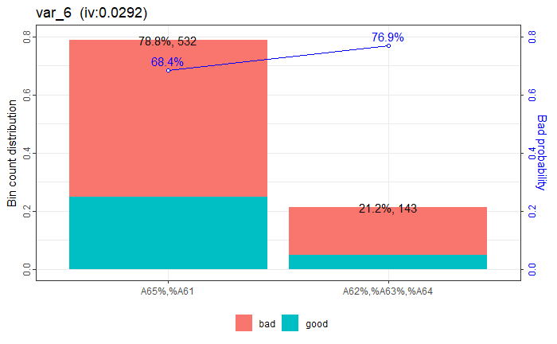

### Variable 13:

| variable | bin | count | count_distr | good | bad | badprob | woe | bin_iv | total_iv | breaks | is_special_values |
| --- | --- | --- | --- | --- | --- | --- | --- | --- | --- | --- | --- |
| var_13 | [-Inf,26) | 129 | 0.1911111 | 52 | 77 | 0.5968992 | -0.46534071 | 0.0447933293 | 0.07716659 | 26 | FALSE |
| var_13 | [26,45) | 405 | 0.6000000 | 118 | 287 | 0.7086420 | 0.03089518 | 0.0005691063 | 0.07716659 | 45 | FALSE |
| var_13 | [45, Inf) | 141 | 0.2088889 | 31 | 110 | 0.7801418 | 0.40859075 | 0.0318041542 | 0.07716659 | Inf | FALSE |

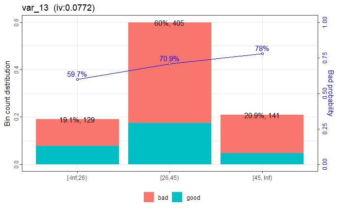

### Variable 4:

| variable | bin | count | count_distr | good | bad | badprob | woe | bin_iv | total_iv | breaks | is_special_values |
| --- | --- | --- | --- | --- | --- | --- | --- | --- | --- | --- | --- |
| var_4 | A48%,%A41 | 75 | 0.1111111 | 12 | 63 | 0.8400000 | 0.80032566 | 5.859176e-02 | 0.166244 | A48%,%A41 | FALSE |
| var_4 | A44%,%A43 | 192 | 0.2844444 | 43 | 149 | 0.7760417 | 0.38484378 | 3.864434e-02 | 0.166244 | A44%,%A43 | FALSE |
| var_4 | A45%,%A42 | 140 | 0.2074074 | 42 | 98 | 0.7000000 | -0.01060455 | 2.337423e-05 | 0.166244 | A45%,%A42 | FALSE |
| var_4 | A40%,%A49%,%A410%,%A46 | 268 | 0.3970370 | 104 | 164 | 0.6119403 | -0.40242688 | 6.898457e-02 | 0.166244 | A40%,%A49%,%A410%,%A46 | FALSE |

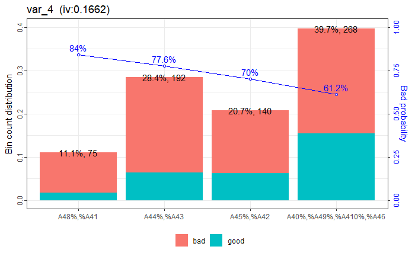

### Variable 12:

[output not shown]

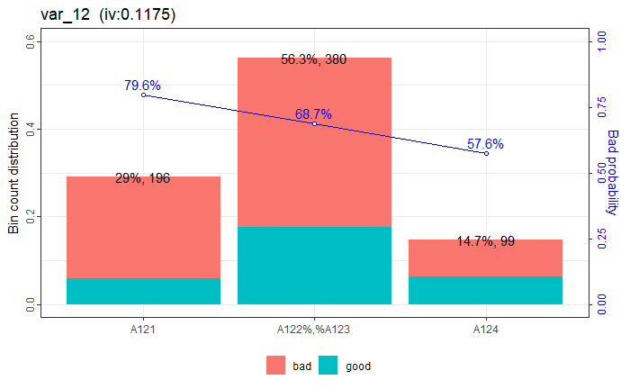

### Variable 14:

| variable | bin | count | count_distr | good | bad | badprob | woe | bin_iv | total_iv | breaks | is_special_values |
| --- | --- | --- | --- | --- | --- | --- | --- | --- | --- | --- | --- |
| var_14 | A143 | 547 | 0.8103704 | 145 | 402 | 0.7349177 | 0.1618159 | 0.02050341 | 0.0973631 | A143 | FALSE |
| var_14 | A142%,%A141 | 128 | 0.1896296 | 56 | 72 | 0.5625000 | -0.6065880 | 0.07685969 | 0.0973631 | A142%,%A141 | FALSE |

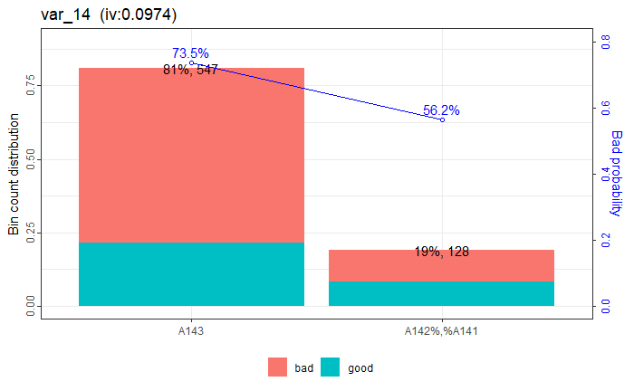

### Variable 15:

| variable | bin | count | count_distr | good | bad | badprob | woe | bin_iv | total_iv | breaks | is_special_values |
| --- | --- | --- | --- | --- | --- | --- | --- | --- | --- | --- | --- |
| var_15 | A152 | 479 | 0.7096296 | 125 | 354 | 0.7390397 | 0.1830808 | 0.02287501 | 0.07620464 | A152 | FALSE |
| var_15 | A151 | 127 | 0.1881481 | 47 | 80 | 0.6299213 | -0.3260234 | 0.02120928 | 0.07620464 | A151 | FALSE |
| var_15 | A153 | 69 | 0.1022222 | 29 | 40 | 0.5797101 | -0.5363188 | 0.03212036 | 0.07620464 | A153 | FALSE |

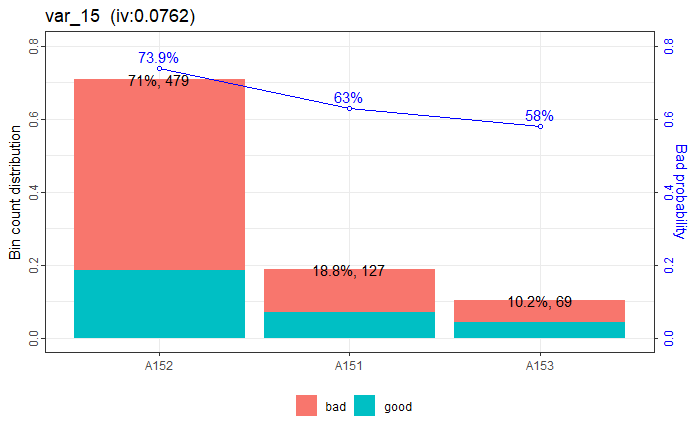

### Variable 7:

| variable | bin | count | count_distr | good | bad | badprob | woe | bin_iv | total_iv | breaks | is_special_values |
| --- | --- | --- | --- | --- | --- | --- | --- | --- | --- | --- | --- |
| var_7 | A71%,%A72 | 156 | 0.2311111 | 62 | 94 | 0.6025641 | -0.44174202 | 0.0486558843 | 0.07098189 | A71%,%A72 | FALSE |
| var_7 | A73 | 222 | 0.3288889 | 64 | 158 | 0.7117117 | 0.04580954 | 0.0006837244 | 0.07098189 | A73 | FALSE |
| var_7 | A74%,%A75 | 297 | 0.4400000 | 75 | 222 | 0.7474747 | 0.22728685 | 0.0216422775 | 0.07098189 | A74%,%A75 | FALSE |

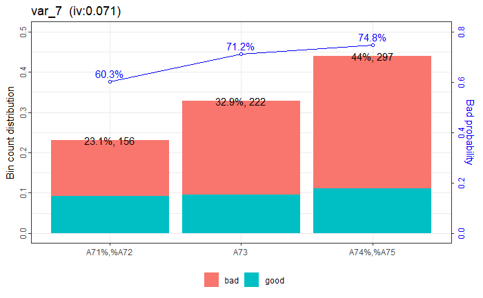

### Variable 9:

| variable | bin | count | count_distr | good | bad | badprob | woe | bin_iv | total_iv | breaks | is_special_values |
| --- | --- | --- | --- | --- | --- | --- | --- | --- | --- | --- | --- |
| var_9 | A93 | 365 | 0.5407407 | 92 | 273 | 0.7479452 | 0.2297808 | 0.02716881 | 0.05624888 | A93 | FALSE |
| var_9 | A94%,%A92%,%A91 | 310 | 0.4592593 | 109 | 201 | 0.6483871 | -0.2459454 | 0.02908007 | 0.05624888 | A94%,%A92%,%A91 | FALSE |

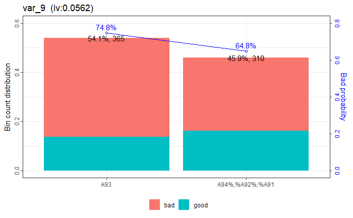

### Variable 8:

| variable | bin | count | count_distr | good | bad | badprob | woe | bin_iv | total_iv | breaks | is_special_values |
| --- | --- | --- | --- | --- | --- | --- | --- | --- | --- | --- | --- |
| var_8 | [-Inf,2) | 87 | 0.1288889 | 17 | 70 | 0.8045977 | 0.557379484 | 3.517188e-02 | 0.04382695 | 2 | FALSE |
| var_8 | [2,4) | 263 | 0.3896296 | 78 | 185 | 0.7034221 | 0.005744585 | 1.284292e-05 | 0.04382695 | 4 | FALSE |
| var_8 | [4, Inf) | 325 | 0.4814815 | 106 | 219 | 0.6738462 | -0.132269778 | 8.642225e-03 | 0.04382695 | Inf | FALSE |

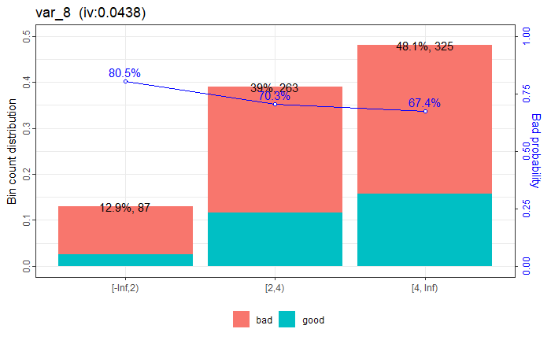

## Modelo Completo

```
Call:
glm(formula = var_21_recode ~ var_1_woe + var_2_woe + var_5_woe +
    var_3_woe + var_6_woe + var_13_woe + var_4_woe + var_12_woe +
    var_14_woe + var_15_woe + var_7_woe + var_9_woe + var_8_woe,
    family = binomial, data = df_train_woe)

Deviance Residuals:
    Min       1Q   Median       3Q      Max
-2.5488  -0.7661   0.3618   0.7327   2.1874

Coefficients:
            Estimate Std. Error z value Pr(>|z|)
(Intercept)   0.8853     0.1034   8.562  < 2e-16 ***
var_1_woe     0.9246     0.1332   6.942 3.86e-12 ***
var_2_woe     0.7051     0.2363   2.984 0.002847 **
var_5_woe     0.9079     0.3080   2.947 0.003204 **
var_3_woe     0.6989     0.2325   3.006 0.002644 **
var_6_woe     1.0812     0.6047   1.788 0.073789 .
var_13_woe    1.0060     0.3827   2.629 0.008565 **
var_4_woe     1.1776     0.2524   4.665 3.08e-06 ***
var_12_woe    0.5736     0.3358   1.708 0.087594 .
var_14_woe    0.9246     0.3195   2.894 0.003803 **
var_15_woe    0.4298     0.3847   1.117 0.263898
var_7_woe     0.6219     0.3751   1.658 0.097280 .
var_9_woe     1.1947     0.4542   2.630 0.008532 **
var_8_woe     1.9501     0.5529   3.527 0.000421 ***
---
Signif. codes:  0 ‘***’ 0.001 ‘**’ 0.01 ‘*’ 0.05 ‘.’ 0.1 ‘ ’ 1

(Dispersion parameter for binomial family taken to be 1)

    Null deviance: 822.11  on 674  degrees of freedom
Residual deviance: 617.25  on 661  degrees of freedom
AIC: 645.25

Number of Fisher Scoring iterations: 5
```

Es posible observar que todas las variables del modelo son significativas utilizando el test de Wald, esto a excepción de la variable “var_15_woe”, por lo tanto es variable será retirada del modelo. Además se ha validado este resultado utilizando la técnica stepwise para elegir las variables del modelo y justamente el modelo entregado es el modelo completo sin variable “var_15_woe”.

```r
modelo_ajustado <- glm(formula(step(modelo_completo,trace=0)),
                       family = binomial, data = df_train_woe)

summary(modelo_ajustado)
```

```
Call:
glm(formula = formula(step(modelo_completo, trace = 0)), family = binomial,
    data = df_train_woe)

Deviance Residuals:
    Min       1Q   Median       3Q      Max
-2.6088  -0.7827   0.3648   0.7312   2.2204

Coefficients:
            Estimate Std. Error z value Pr(>|z|)
(Intercept)   0.8825     0.1032   8.556  < 2e-16 ***
var_1_woe     0.9292     0.1330   6.988 2.79e-12 ***
var_2_woe     0.7038     0.2351   2.994 0.002756 **
var_5_woe     0.9000     0.3077   2.925 0.003448 **
var_3_woe     0.7090     0.2314   3.064 0.002183 **
var_6_woe     1.0851     0.6043   1.796 0.072545 .
var_13_woe    1.0184     0.3831   2.658 0.007855 **
var_4_woe     1.1709     0.2523   4.641 3.46e-06 ***
var_12_woe    0.7260     0.3086   2.352 0.018651 *
var_14_woe    0.9162     0.3191   2.871 0.004093 **
var_7_woe     0.6074     0.3747   1.621 0.105072
var_9_woe     1.2236     0.4531   2.701 0.006923 **
var_8_woe     1.9434     0.5522   3.519 0.000433 ***
---
Signif. codes:  0 ‘***’ 0.001 ‘**’ 0.01 ‘*’ 0.05 ‘.’ 0.1 ‘ ’ 1

(Dispersion parameter for binomial family taken to be 1)

    Null deviance: 822.11  on 674  degrees of freedom
Residual deviance: 618.50  on 662  degrees of freedom
AIC: 644.5

Number of Fisher Scoring iterations: 5
```

## Analisis de correlaciones y VIF.

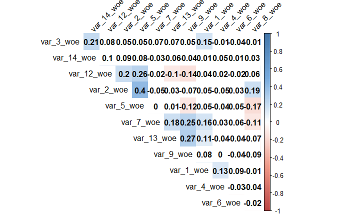

```r
col <- colorRampPalette(c("#BB4444", "#EE9988", "#FFFFFF", "#77AADD", "#4477AA"))
corrplot(correlations, method="color", col=col(200),
         type="upper", order="hclust",
         addCoef.col = "black",
         tl.col="black", tl.srt=45,
         p.mat = p.mat, sig.level = 0.01, insig = "blank",
         diag=FALSE )
```

El nivel de correlaciones entre los predictores es baja por lo tanto, todas las variables pueden estar dentro del modelo. Otra manera de validar esto es analizando el VIF.

```r
vif(modelo_completo)
```

| variable | gvif |
| --- | --- |
| var_1_woe | 1.047769 |
| var_2_woe | 1.258058 |
| var_5_woe | 1.463842 |
| var_3_woe | 1.057926 |
| var_6_woe | 1.026951 |
| var_13_woe | 1.144408 |
| var_4_woe | 1.052906 |
| var_12_woe | 1.362820 |
| var_14_woe | 1.081899 |
| var_15_woe | 1.210456 |

[output cut: 3 more lines]

Todos los valores se encuentran dentro del intervalo tolerable.

## Scorecard.

La libreria utilizada nos entrega un puntaje que no se encuentra en la escala solicitada, sin embargo es posible hacer un rescalamiento de score, en el siguiente grafico de densidad es posible observar que la distribución del score no se ve afectada al hacer el cambio de escala.

### Score original

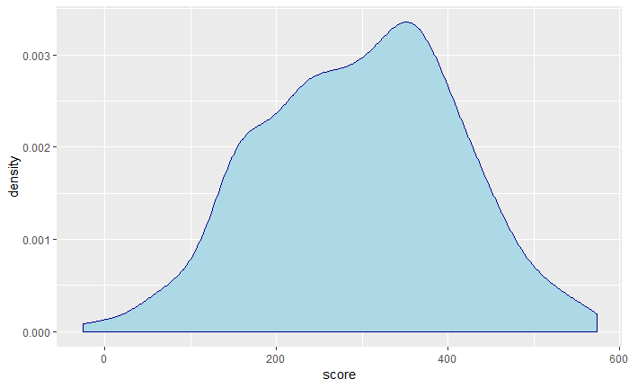

```r
ggplot(df_train, aes(x=score))+
  geom_density(color="darkblue", fill="lightblue")
```

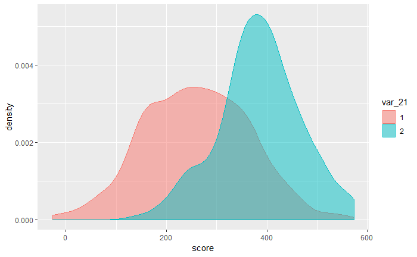

```r
df_train$var_21 <- as.factor(df_train$var_21)

ggplot(df_train, aes(x=score, fill=var_21, color=var_21)) +
  geom_density(position="identity", alpha=0.5)
```

### Score en escala [0,1]

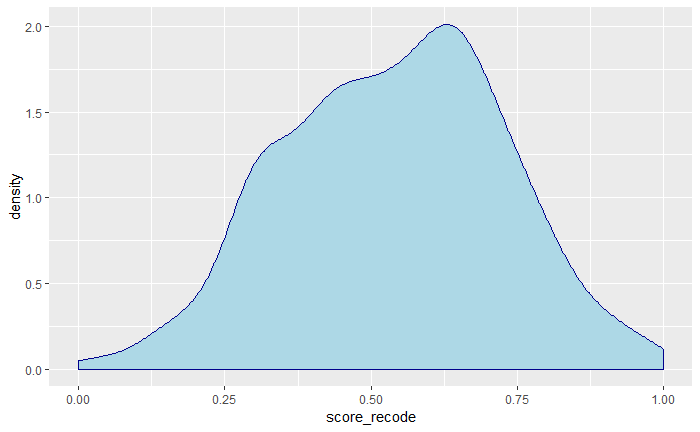

```r
ggplot(df_train, aes(x=score_recode))+
  geom_density(color="darkblue", fill="lightblue")
```

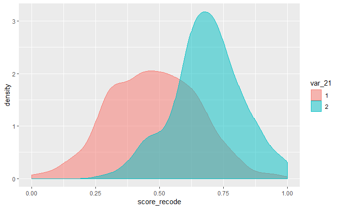

```r
ggplot(df_train, aes(x=score_recode, fill=var_21, color=var_21)) +
  geom_density(position="identity", alpha=0.5)
```

## Gain-Table

### Base Entrenamiento.

| Intervalo Score | count | cum_count | good | cum_good | bad | cum_bad | count_distr | badprob | cum_badprob | approval_rate |
| --- | --- | --- | --- | --- | --- | --- | --- | --- | --- | --- |
| [-Inf,0.2954924875) | 66 | 66 | 65 | 65 | 1 | 1 | 0.0977778 | 0.0151515 | 0.0151515 | 0.0977778 |
| [0.2954924875,0.3656093489) | 69 | 135 | 67 | 132 | 2 | 3 | 0.1022222 | 0.0289855 | 0.0222222 | 0.2000000 |
| [0.3656093489,0.4307178631) | 66 | 201 | 62 | 194 | 4 | 7 | 0.0977778 | 0.0606061 | 0.0348259 | 0.2977778 |
| [0.4307178631,0.489148581) | 69 | 270 | 57 | 251 | 12 | 19 | 0.1022222 | 0.1739130 | 0.0703704 | 0.4000000 |
| [0.489148581,0.5492487479) | 66 | 336 | 55 | 306 | 11 | 30 | 0.0977778 | 0.1666667 | 0.0892857 | 0.4977778 |
| [0.5492487479,0.6043405676) | 65 | 401 | 49 | 355 | 16 | 46 | 0.0962963 | 0.2461538 | 0.1147132 | 0.5940741 |
| [0.6043405676,0.6477462437) | 70 | 471 | 42 | 397 | 28 | 74 | 0.1037037 | 0.4000000 | 0.1571125 | 0.6977778 |
| [0.6477462437,0.6994991653) | 68 | 539 | 32 | 429 | 36 | 110 | 0.1007407 | 0.5294118 | 0.2040816 | 0.7985185 |
| [0.6994991653,0.7696160267) | 64 | 603 | 24 | 453 | 40 | 150 | 0.0948148 | 0.6250000 | 0.2487562 | 0.8933333 |
| [0.7696160267, Inf) | 72 | 675 | 21 | 474 | 51 | 201 | 0.1066667 | 0.7083333 | 0.2977778 | 1.0000000 |

### Base validación

| Intervalo Score | count | cum_count | good | cum_good | bad | cum_bad | count_distr | badprob | cum_badprob | approval_rate |
| --- | --- | --- | --- | --- | --- | --- | --- | --- | --- | --- |
| [-Inf,0.2687813022) | 21 | 21 | 21 | 21 | 0 | 0 | 0.0933333 | 0.0000000 | 0.0000000 | 0.0933333 |
| [0.2687813022,0.3772954925) | 24 | 45 | 22 | 43 | 2 | 2 | 0.1066667 | 0.0833333 | 0.0444444 | 0.2000000 |
| [0.3772954925,0.4357262104) | 22 | 67 | 18 | 61 | 4 | 6 | 0.0977778 | 0.1818182 | 0.0895522 | 0.2977778 |
| [0.4357262104,0.4774624374) | 23 | 90 | 20 | 81 | 3 | 9 | 0.1022222 | 0.1304348 | 0.1000000 | 0.4000000 |
| [0.4774624374,0.5141903172) | 21 | 111 | 18 | 99 | 3 | 12 | 0.0933333 | 0.1428571 | 0.1081081 | 0.4933333 |
| [0.5141903172,0.5676126878) | 23 | 134 | 12 | 111 | 11 | 23 | 0.1022222 | 0.4782609 | 0.1716418 | 0.5955556 |
| [0.5676126878,0.6393989983) | 23 | 157 | 17 | 128 | 6 | 29 | 0.1022222 | 0.2608696 | 0.1847134 | 0.6977778 |
| [0.6393989983,0.7161936561) | 23 | 180 | 13 | 141 | 10 | 39 | 0.1022222 | 0.4347826 | 0.2166667 | 0.8000000 |
| [0.7161936561,0.774624374) | 22 | 202 | 12 | 153 | 10 | 49 | 0.0977778 | 0.4545455 | 0.2425743 | 0.8977778 |
| [0.774624374, Inf) | 23 | 225 | 5 | 158 | 18 | 67 | 0.1022222 | 0.7826087 | 0.2977778 | 1.0000000 |

## Indicadores

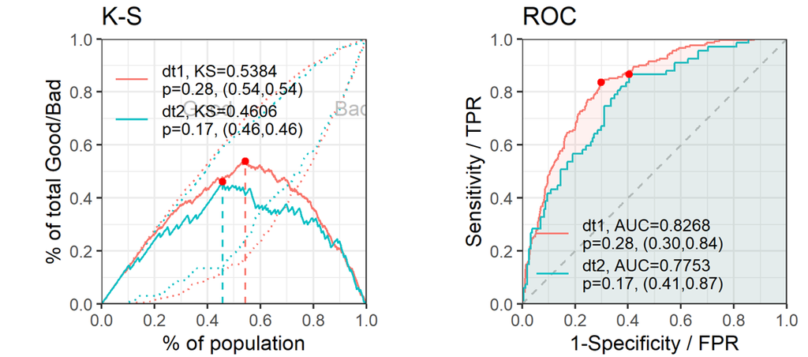

Tanto para la base de entrenamiento y validación se logran buenos indicadores, esto hablando de indicadores clásicos para este tipo de modelos como K-s, ROC y GINI. Sin embargo es posible ver la inestabilidad de estos modelos, ya que varian en alrededor de 4% a 8% por indicador, esto podria explicarse por el tamaño de la muestra.

Por otra parte es posible ver la distribución del bad rate por los tramos del score y además la distribución del score.

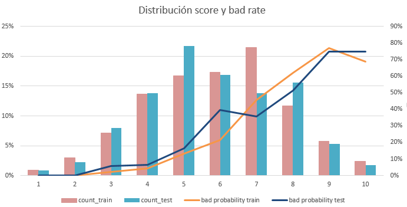

## Precio del seguro por persona.

### Base entrenamiento

```r
group_by(df_train, var_21) %>%
  summarise(n = n(), min_precio_base= min(precio_base) , p10 = quantile(precio_base, probs = 0.1), p25 = quantile(precio_base, probs = 0.25),mean_precio_base=mean(precio_base), median_precio_base=median(precio_base), p75 = quantile(precio_base, probs = 0.75), p90 = quantile(precio_base, probs = 0.9), p99 = quantile(precio_base, probs = 0.99), max_var5 = max(precio_base),sd=sd(precio_base))
```

[output not shown]

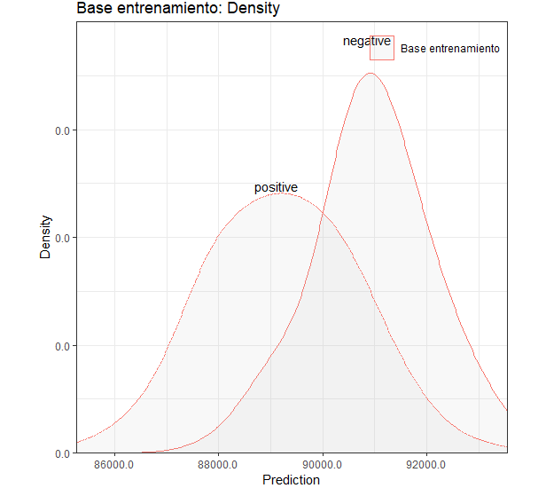

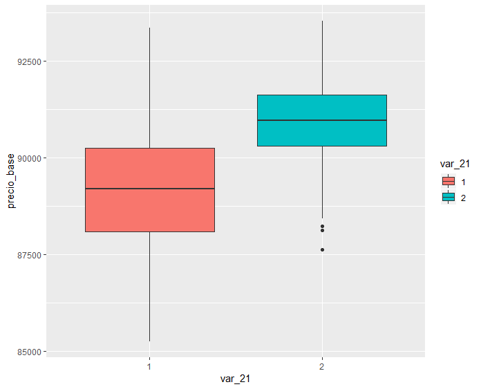

### Base validación

```r
group_by(df_test, var_21) %>%
  summarise(n = n(), min_precio_base= min(precio_base) , p10 = quantile(precio_base, probs = 0.1), p25 = quantile(precio_base, probs = 0.25),mean_precio_base=mean(precio_base), median_precio_base=median(precio_base), p75 = quantile(precio_base, probs = 0.75), p90 = quantile(precio_base, probs = 0.9), p99 = quantile(precio_base, probs = 0.99), max_var5 = max(precio_base),sd=sd(precio_base))
```

| var_21 | n | min_precio_base | p10 | p25 | mean_precio_base | median_precio_base | p75 | p90 | p99 | max_var5 | sd |
| --- | --- | --- | --- | --- | --- | --- | --- | --- | --- | --- | --- |
| 1 | 158 | 85261.81 | 87149.00 | 88173.54 | 89043.58 | 88979.61 | 90062.04 | 90911.54 | 92058.46 | 93539.66 | 1389.575 |
| 2 | 67 | 87604.35 | 88801.94 | 89479.70 | 90426.36 | 90578.59 | 91394.53 | 91913.04 | 92799.00 | 93302.77 | 1231.995 |

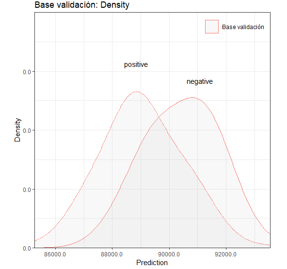

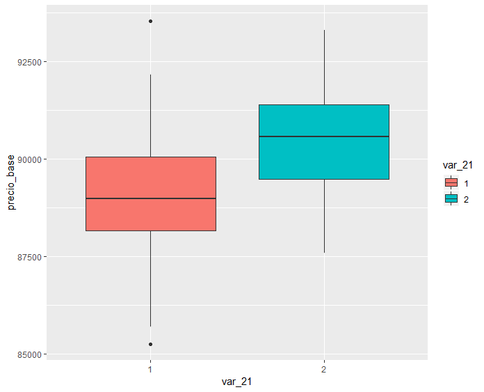

# Puntaje de corte.

En la siguiente imagen se encuentra un gain table donde se encuentran los indicadores del modelo, por otra parte la columna “ROI” indica el tramo de score donde se maximiza la ganancia en dinero, tomando en cuenta la información entregada por enunciado.

- Es 5 veces peor clasificar un cliente como bueno cuando es malo, que malo cuando es bueno.

Por lo tanto, el puntaje de corte puede ser elegido de dos maneras:

1. Tramo de score donde donde se maximiza los indicadores de discriminación.
2. Tramo de score en el cual se maximiza el ROI.

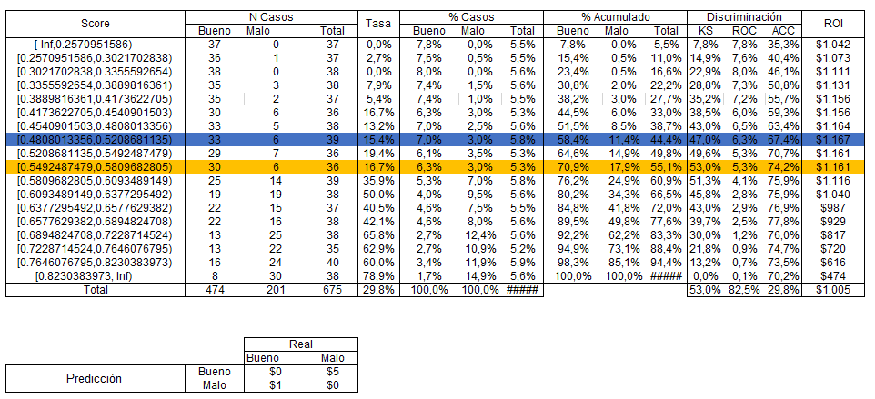

# Conclusión.

El modelo presenta buenos indicadores en base a su clasficación, esto debido a variables predictoras con alto porcentaje de poblamiento, sin embargo el modelo presenta inestabilidad en el bad rate a lo largo de los tramos del score, por otra parte la inestabilidad del modelo no es abrupta, considerando que el tamaño de la base es de 900 registros donde además, esta base fue separada en 75% entrenamiento y 25% validación.

El modelo logra asignar valores de precios más altos para los personas que son mas riesgosas, por lo tanto el modelo logra aterrizar el sentido lógico del desafio.

Próximos pasos:

1. Mayor recopilación de registros para el ajuste del modelo.
2. Validación del modelo con una base mas grande.
3. Poseer las fechas de evaluación de los clientes para evaluar la distribución del score en el tiempo, junto con sus indicadores.
4. Al tener mayor cantidad de registros evaluar atributos segmentadores para tener posibilidad de generar un modelo segmentado, con la finalidad de aumentar la calidad del modelo.